# Assignment02

Tejaswini Sengaonkar

2023-03-14

# Assignment 2

# Task 1: Examine the data

Q Now open the data (say in Excel), examine it and answer the following questions: The data is obviously not pre-processed – can you spot the problems?

Following problems can be spotted in the data -

1. The data is structured in such a way that it is readable for humans. The same data cannot be read by the computer easily.
2. It consists of empty cells indicating null values. For example for Sensible heating in large offices is not present.
3. It has duplicate data, having identical rows of data, such as at for Indoor Temperature at peak.
4. We can see certain values where the data is significantly different from the rest of the data. It can be seen in case of heating energy in large offices of El Paso.

Q How would you address the challenges identified above? Briefly summarize your thoughts.

We can use following approaches for handling above problems -

1. The structure of the data can we changed using some tidyr package functions like gather and mutate.These will help in creating the data which can be read by computers.
2. Null or empty values can cause deviation in the result of data analysis. To avoid that we can fill the empty values with approximate values of mean or median, which is called as Imputation technique.
3. For duplicate data, aggregation of data can be beneficial. It would create an aggregate temperature value that will reduce multiple entries.
4. We can see some extreme values in data known as ‘data outliers’. For addressing them, we can either remove the values or transform the data with the help of mathematical and statistical techniques.

# Task 2: Clean the data

Process the raw data into a clean format. You may consider the following guideline in your script. Show your script.

1. Load the .xlsx data into R [Hint: check the read_xlsx function from the {readxl} package.]
2. Create sensible column names, e.g. weather, description etc.
3. Create new attribute and fill-in NA values that were the results of ‘Merged Cell’ from the spreadsheet. [Hint: this can be hard if you try to use for loop; check the na.locf function from the {zoo} package.]
4. Turn data in to a clean format. [Hint: you may use reshaping functions]

```r
# Read data from excel

library("readxl")
raw.df<-readxl::read_xlsx("C:/Users/tejas/Downloads/simulation_outpu1_raw.xlsx",
                          skip=7,col_names= FALSE)
# Add data to data frame variable

dataframe<-raw.df

library(tidyverse)
```

```r
# Create column names

header<-expand.grid(x =c('concrete', 'curtain-wall'), y = 'offices', z
                    = c('small', 'medium', 'large'))%>%mutate(nn = paste(x,y,z, sep =
                                                                           '_'))%>%pull(nn)


#Append other column names to raw.df

names(dataframe) <- c('weather',
                      'description', header)

# Add a row on top of the data with all null values

x1<-as.data.frame(matrix(rep(NA,length(dataframe)),nrow=1))
names(x1)<-names(dataframe)
dataframe2<-bind_rows(x1,dataframe)%>%
  mutate(group = ifelse(is.na(description), 'overall',
                        ifelse(description=='Sensible Cooling', 'sensible_cooling',
                               ifelse(description=='Sensible Heating', 'sensible_heating',NA))))

library(zoo)
# Fill NA values

group.vt<-zoo(dataframe2$group)
dataframe2$group<-na.locf(group.vt)
dataframe2$group<-as.character(dataframe2$group[1:length(dataframe2$group)])

num_na_per_row.vt<-apply(dataframe2, 1, function(x) sum(is.na(x)))
dataframe2<-dataframe2[which(num_na_per_row.vt<7),]

weather.vt<-zoo(dataframe2$weather)
dataframe2$weather<-na.locf(weather.vt)
dataframe2$weather<-as.character(dataframe2$weather[1:length(dataframe2$weather)])

# Wrangle and tidy the data

dataframe3<-dataframe2%>% gather(key =
                                   'structure',value='value',-group,-weather,-description)%>%
  separate(structure,
           c('office_type',"office","office_size"),sep="_")%>% select(-office)

glimpse(dataframe3)
```

```
## Rows: 918
## Columns: 6
## $ weather     <chr> "Very Hot Humid (Honolulu, HI)", "Very Hot Humid (Honolulu…
## $ description <chr> "Heating energy [GJ]", "Cooling energy [GJ]", "Total Cosum…
## $ group       <chr> "overall", "overall", "overall", "sensible_cooling", "sens…
## $ office_type <chr> "concrete", "concrete", "concrete", "concrete", "concrete"…
## $ office_size <chr> "small", "small", "small", "small", "small", "small", "sma…
## $ value       <dbl> 0.00000, 47.07000, 162.47000, 0.25600, 0.30800, 23.89000, …
```

# Task 3

For small office with sensible cooling in place, how does the outdoor temperature at peak load differ by weather? Does the pattern vary by office type?

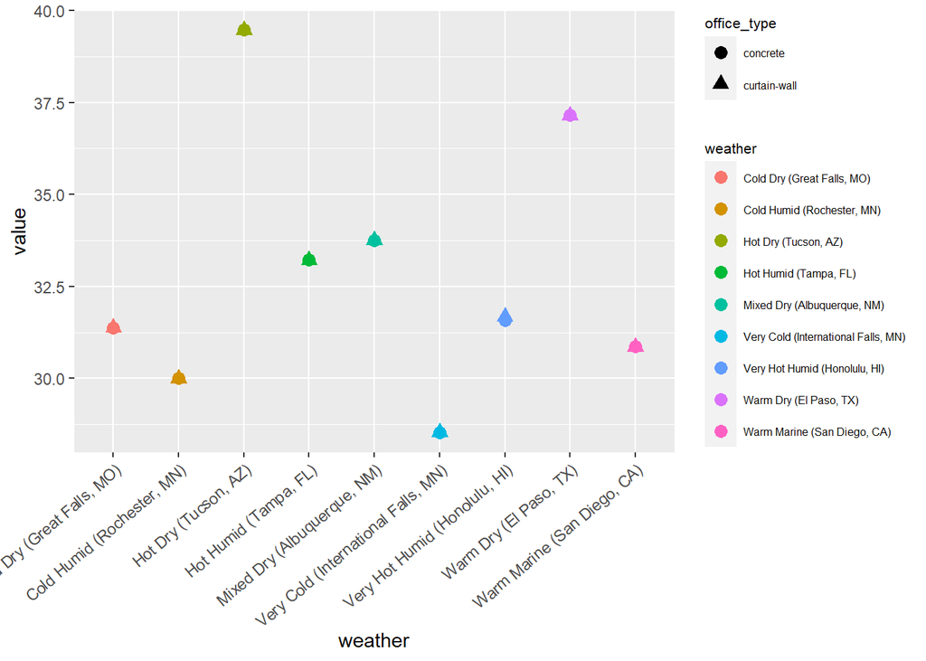

```r
dataframe3 %>% filter(office_size == 'small') %>%
  filter(description == "Outdoor Temperature at Peak Load [C]" & group=='sensible_cooling') %>%
  ggplot(aes( x = weather,y = value,color=weather,shape = office_type)) + geom_point(size = 3) +
  theme(axis.text.x =element_text(angle = 40, hjust = 1),
        legend.position="right",
        legend.text = element_text(size=6),
        legend.title = element_text(size=8))
```

As per the scatter graph, it is visible that outdoor temperature at peak differs as per the weather conditions. The pattern does not vary by office type.

Do any of these factors affect the total energy consumption: office_type; office_size and weather? If so, which one has the most significant impact?

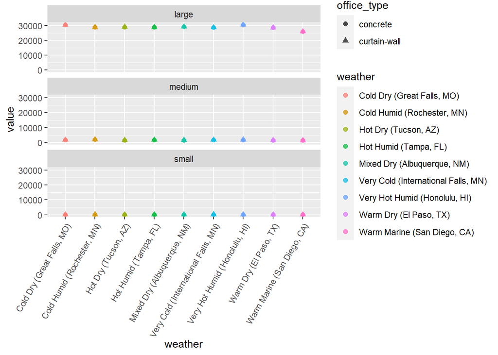

```r
dataframe3 %>% filter(description == 'Total Cosumption [GJ]') %>%
  ggplot(aes(x = weather, y = value, color = weather, shape = office_type)) +
  geom_point(size = 2, alpha = 0.7) +
  facet_wrap(~office_size,nrow = 3, scales = 'fixed') +
  theme(axis.text.x = element_text(angle = 60, hjust = 1),
        legend.position = 'right')
```

Total energy consumption seems to be affected by the given factors. It is majorly affected due office_size.